# MTH6139 Time Series

Coursework 1

Ethan Andrew Haley

Spring term 2025

# Introduction

The S&P500 is a market index of the 500 most valuable companies in the USA, making it an incredible valuable tool for not only measuring the benchmark of the US equity market, but also a tool for people wanting to invest and develop their wealth, or ensure they have money saved for their retirement and pension. Being such a valuable index, we want to ensure that we can try and track how it with grow with time in order to understand not only what past performance can tell us, but also to investigate whether there are any times in which performance decreases and people could potentially invest in a “dip”.

Naturally, a way in which we can do this is via a time series, and with Meta’s Prophet forecasting system, we can also predict what it’s value will be for upcoming periods, a spectacular insight and asset for all types of investors.

However, we do have some requirements in order for our time series to be an accurate and fair fit, namely that our residuals must follow a random “white noise” trend in order for our model to be fair.

# Section 1: Completing Set-up

In order to begin working on constructing our time series, we first need to ensure that we lay the correct ground work and set-up to ensure we have what we need.

The first step of this is ensuring that we active the correct packages in R, which are:

```r
library(prophet)
library(readxl)
```

We need these packages for 2 different reasons:

- The prophet packages will ensure that we have access to the correct package to conduct our forecasting and make our time series.
- The readxl package allows us to read our data into R and allow us to then use it to create our time series use the data we need.

Following this, we then need to import our data and create a data frame for it.

```r
Data=read_excel("Inflation Adjusted S&P500 Values.xlsx")
ds= Data$Date
y= Data$Value
DataFrame=data.frame(ds, y)
```

We now have our data in R for the inflation adjusted S&P500 values, where we have 120 values, which equates to 1 value for the index each month for the years 2016-2025. We have also had to ensure that we call our time values and data values “ds” and “y” respectively, as otherwise prophet will not allow us to conduct our forecasting.

Before we continue, we can see what the plot of the data actually looks like.

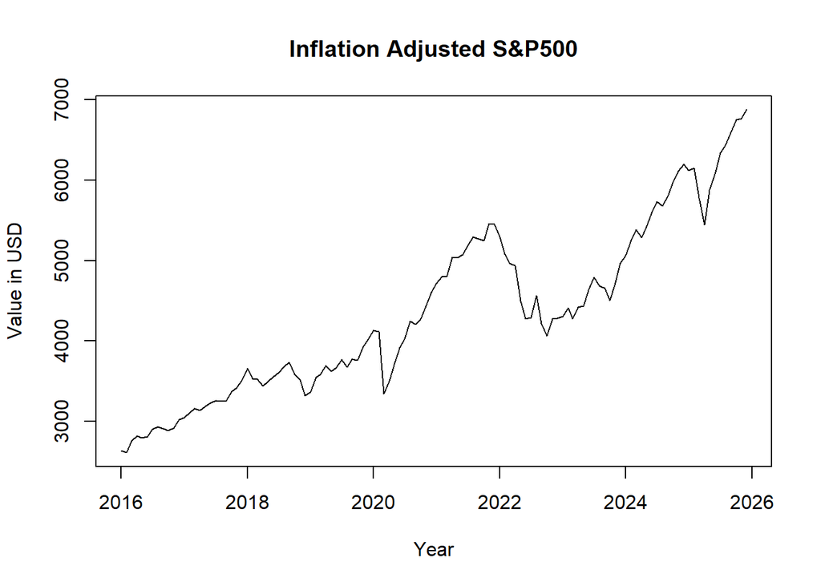

As we see above, there are several observations in which we can make, such as:

- The index appears to be operating on an upward trend in recent years.
- There is potentially some seasonality with a pattern of dips after a period of high rises.
- We have a large dip in early 2022 that took until 2024 to recover, a dip that could affect the accuracy of our model.

In our exploration of this data, we will see if we can handle these observations and mitigate any concerning aspects of them.

# Section 2: A Linear Regression Model?

A time series is a sequence of data points which are recorded at regular intervals, and often has 3 components:

- Trend.
- Seasonality.
- Random Error.

However, there is another type of model that we could use to fit our data, which is a simple linear regression model. A simple linear regression model is on that tries to a response variable to an explanatory variable in the form:

- y= a + bt + e

Whereby:

- y= Response Variable.
- a= Intercept Term.
- b= Slope Term.
- t= Explanatory Variable.
- e= Random Error.

We note that sometimes, a simple linear regression model is used in a time series, however the time series will have the extra component of the seasonality. However, when investigating data such as this, we must ask the question of whether we could fit a simple linear regression model before trying to use prophet. We can do this with the following code.

```r
LinearModel= lm(y~ds)
summary(LinearModel)
```

```
##
## Call:
## lm(formula = y ~ ds)
##
## Residuals:
##     Min      1Q  Median      3Q     Max
## -899.28 -179.63   36.23  185.59  827.54
##
## Coefficients:
##               Estimate Std. Error t value Pr(>|t|)
## (Intercept) -1.310e+04  6.544e+02  -20.02   <2e-16 ***
## ds           1.085e-05  4.063e-07   26.71   <2e-16 ***
## ---
## Signif. codes:  0 '***' 0.001 '**' 0.01 '*' 0.05 '.' 0.1 ' ' 1
##
## Residual standard error: 405.4 on 118 degrees of freedom
## Multiple R-squared:  0.8581, Adjusted R-squared:  0.8569
## F-statistic: 713.6 on 1 and 118 DF,  p-value: < 2.2e-16
```

However, we need to ensure that we examine our residuals.

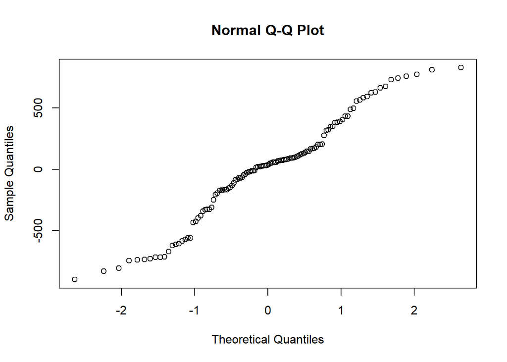

```r
qqnorm(residuals(LinearModel))
```

We can see here that our qqplot does appear to follow a straight line, however there are some areas at the first and end tail that could follow a more straight line. We can validate this with the Shapiro-Wilk Test.

```r
shapiro.test(residuals(LinearModel))
```

```
##
##  Shapiro-Wilk normality test
##
## data:  residuals(LinearModel)
## W = 0.96792, p-value = 0.00578
```

Ultimately, our residuals have failed the Shapiro-Wilk test with a p-value of less than 1%, meaning they are not normally distributed which fails one of our assumptions.

This now leads us onto creating our time series using the prophet tools.

# Section 3: First Prophet Time Series

## Creating our Time Series

Prophet is first and foremost a forecasting package for time series, meaning it will take data which we give it, create a time series and then use it to predict some of the values for our future times and dates. Given this, it is not enough for us to simple create the time series. While we can initially use prophet to create the time series, making predictions is where this system is truly effective and will shine. We need to ensure that we make predictions by supplying it with the future dates which we would like it to make predictions and forecasts for. For this, we need to utilise the make_future_dataframe function, upon which we can then use the prophet forecasting system.

```r
TSModel=prophet(DataFrame, weekly.seasonality=FALSE, daily.seasonality=FALSE)
FutureDates= make_future_dataframe(TSModel, 8, freq="month")
Prediction=predict(TSModel, FutureDates)
```

As we can see above, we have created the first time series using the prophet system. It is important to note that weekly seasonality and daily seasonality is disabled automatically, which we want to ensure we keep as our data is in months. However, we want to ensure that yearly seasonality remains, as this allows us to explore if there are any patterns in certain months of the year. Furthermore, we have created our future dates variable, which contains not only the date values from the last 10 years, but also another 8 months. Given our data lasts up until the end of 2025, we will have 3 values for which we know what the reality of the S&P500 inflation adjusted value actually was, so we can explore how accurate our model was. Finally, we have created our predictions for this time series, which we can better explore with a plot of the data.

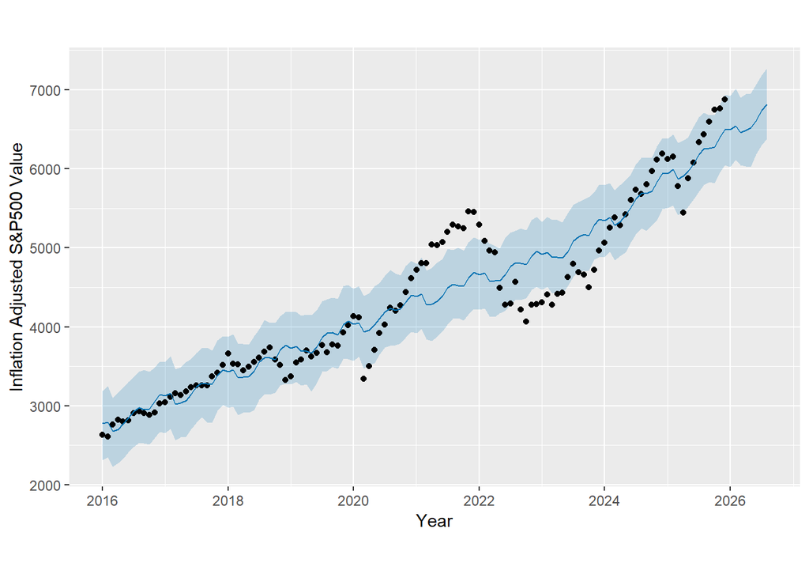

From our model we can see that:

- We have an upper and lower bound for our predictions.
- We have the actual reality of the data and how the value of the index changed.
- 2020-2022 proved to be a very difficult period for predictions, with there being adverse growth and change in these two years.
- Our model is predicting continued stable growth for the next 8 months at a more linear rate.

When looking at what we actual inflation adjusted S&P500 values were, we see that they were the following for each month:

- January 2026- 6929.12 USD
- February 2026- 6893.81 USD
- March 2026- 6822.41 USD

Using the tail of our Prediction variable, we can see that our model predicts:

```r
tail(Prediction[, c("ds","yhat")], 8)
```

```
##             ds     yhat
## 121 2026-01-01 6495.072
## 122 2026-02-01 6542.095
## 123 2026-03-01 6462.040
## 124 2026-04-01 6490.485
## 125 2026-05-01 6518.943
## 126 2026-06-01 6612.946
## 127 2026-07-01 6744.572
## 128 2026-08-01 6815.841
```

As we can see here, we are not fully accurate with our predicted values, which was perhaps to be expected as we saw with our original graph that our actual values were above our model. However, our model was able to predict a slight decrease from the month of February to March, showing that our model does have some applications. If we look at the upper bound of our prediction.

```r
tail(Prediction[, c("ds","yhat_upper")], 8)
```

```
##             ds yhat_upper
## 121 2026-01-01   6920.441
## 122 2026-02-01   7013.871
## 123 2026-03-01   6899.732
## 124 2026-04-01   6943.420
## 125 2026-05-01   6953.631
## 126 2026-06-01   7065.399
## 127 2026-07-01   7186.627
## 128 2026-08-01   7277.685
```

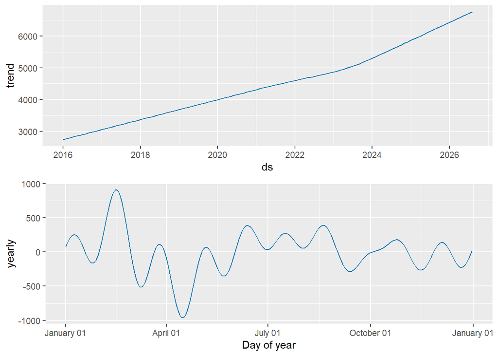

```r
prophet_plot_components(TSModel, Prediction)
```

## Trend Component

We first analyse our trend component, seen below here.

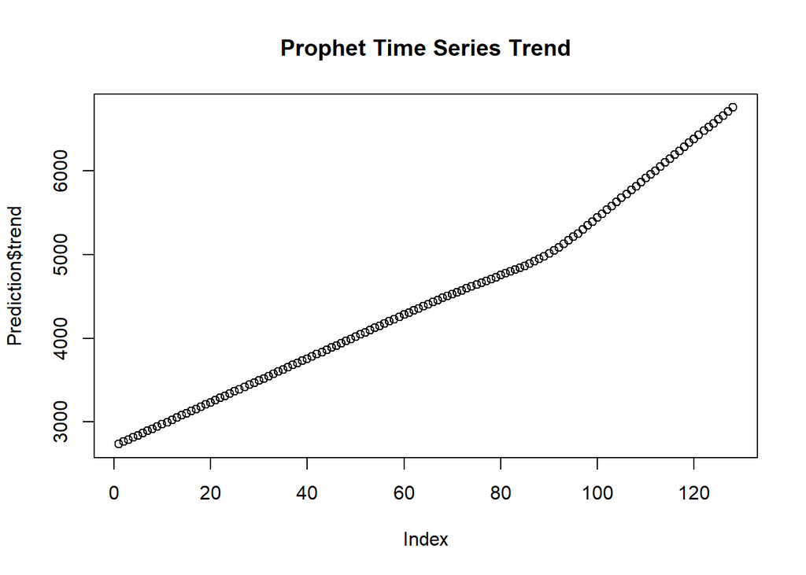

Now upon analysing the trend component, we observe that:

- The relationship over time appears to be a more linear one for the first 7 years, meaning from 2016-2022.
- We seem to have an upwards tick in the last 3 years where we increase at a higher rate.
- Our higher increase can make the graph seem to be potentially applicable for logarithms.
- Much of our random variation is not present here, making it be held in the seasonality component.

We can then further analyse the time series further when we look the seasonality component.

## Seasonality Component

We can then analyse the seasonality component of our time series.

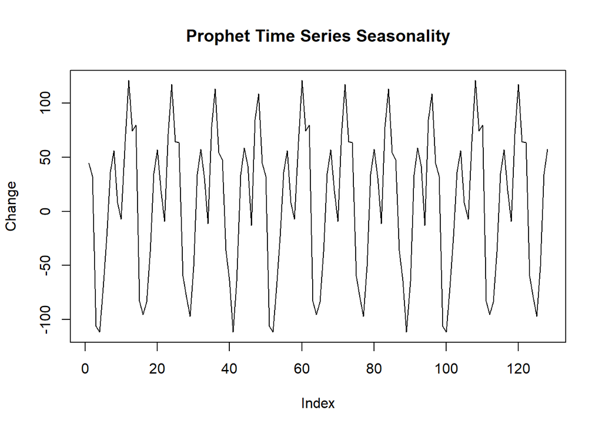

Now this shows us our seasonality across the whole year, however we can gain better insights if we look at a 12 month period, especially since the seasonality repeats every 12 months.

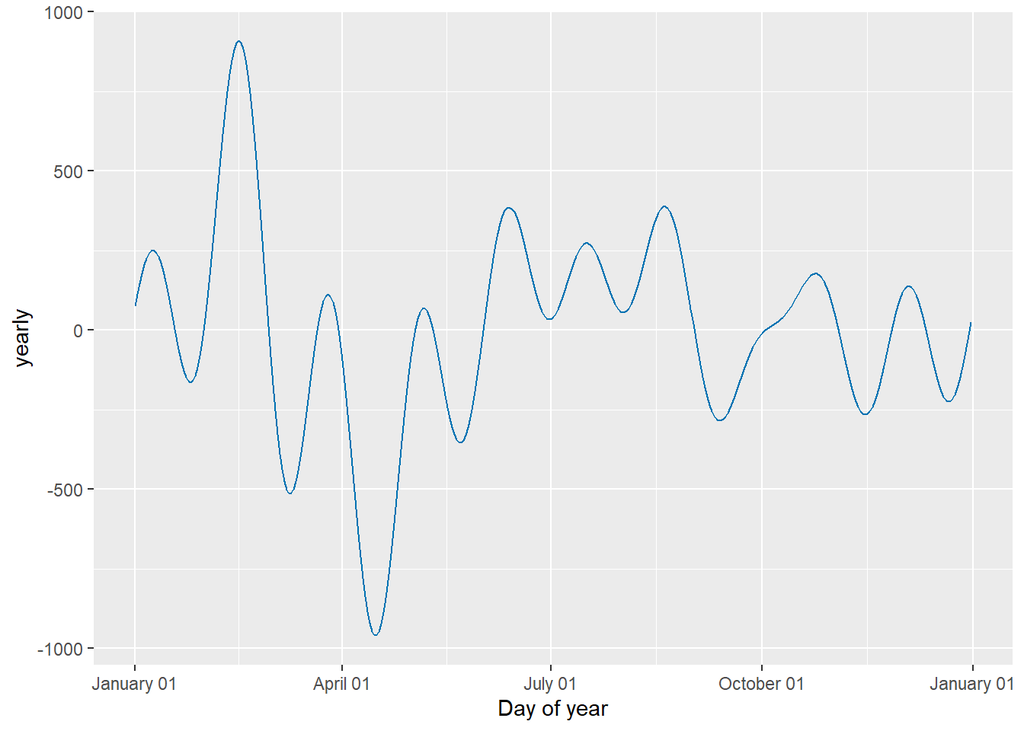

Now when looking at this model, we gain valuable insights into how the index operates over a 12 month period:

- Firstly, the index performs well right as the year starts.
- It then takes a huge dip in its value around April time.
- The index experiences stable recover in the summer months, perhaps reflecting a smaller summer sales slump.
- The index again experiences changes in the winter months, with this period sometimes being when presidential elections happen, as well as the peak quarter for companies.

We now must analyse the residuals to ensure that our model can be appropriate.

## Residuals

We can construct our residuals in the following way.

```r
Residuals= y - Prediction$yhat[1:nrow(DataFrame)]
```

Ultimately, residuals measure how well our model fits to the data, and we want to ensure that they are random and show no pattern, almost following a “white noise” trend in the data.

We can then see and analyse the residuals below.

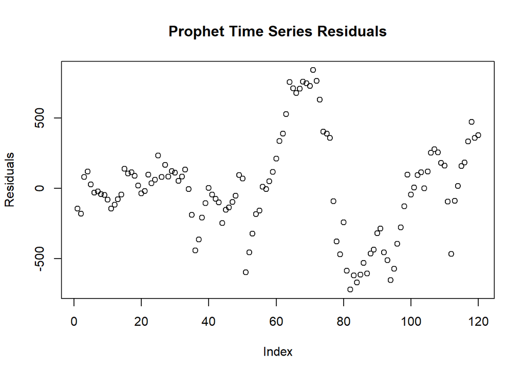

Now here, we do have an issue with our residuals, as they do not appear to follow a white noise random trend, but rather are following a pattern that is not too dissimilar from our original plot.

To fully verify whether our residuals are white noise, we can conduct a Box Test in R. This tests the null hypothesis that our residuals do follow a white noise type distribution, meaning that we want our P-Value to be as high as possible in order to verify this.

```r
Box.test(Residuals, type="Ljung-Box")
```

```
##
##  Box-Ljung test
##
## data:  Residuals
## X-squared = 101.98, df = 1, p-value < 2.2e-16
```

As we can see here, we have failed the Box-Ljung test, meaning that our residuals are not distributed according to white noise. Now in this scenario there is one of two things that we can do:

- Try to build our model again, this time without seasonality.
- Approach the model from a different angle.

Firstly, let us try and construct our model again without seasonality.

## Removing Seasonality

Now, we can recall that give our data was monthly data, the only seasonality that we had was yearly seasonality, which is something that we can easily disable in building our model again. We will also need to build our FutureDates and Prediction variables again, however this used the same code as before.

```r
TSModel= prophet(DataFrame, yearly.seasonality = FALSE, weekly.seasonality=FALSE, daily.seasonality=FALSE)
FutureDates= make_future_dataframe(TSModel, 8, freq="month")
Prediction= predict(TSModel, FutureDates)
```

Now when we look at our model, we will potentially see some changes.

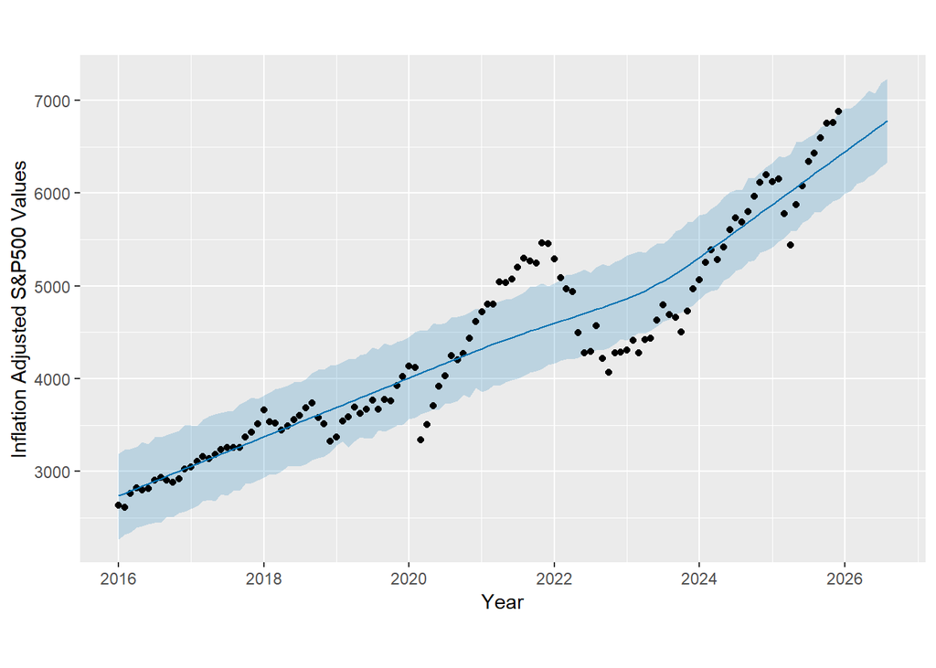

Here, notice that our model is now determined entirely by the trend component, which has remained virtually unchanged from our last model. The effect that this will have on our residuals remains to be seen, however we can predict that this will potentially not help to satisfy the white noise assumption that we want to fulfil, as we still have the data in the 2020-2022 period massively going above where our model predicts.

We now reconstruct and plot of residuals for this new model.

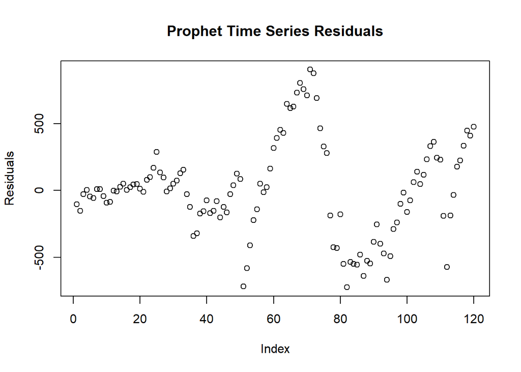

```r
Residuals= y - Prediction$yhat[1:nrow(DataFrame)]
plot(Residuals, main="Prophet Time Series Residuals")
```

Once again, we can already see that our residuals are following a pattern and do not appear to be white noise. We also conduct the Box Test to check this.

```r
Box.test(Residuals, type="Ljung-Box")
```

```
##
##  Box-Ljung test
##
## data:  Residuals
## X-squared = 99.061, df = 1, p-value < 2.2e-16
```

Now whole our X-squared value has decreased marginally, it has not decreased enough for us to use this data for a time series, as we still fail the assumption that our residuals are distributed according to white noise.

# Section 4: Utilising Logarithms

When our model fails in the way that is has, it is often due to the fact that we try to fit data which is actually exponential to a more linear distribution. In order to ensure that our data can actually follow a more linear relationship, we utilise logarithms.

## Creating our Time Series

As mentioned, we need to first ensure that we take logarithms of our S&P500 values, upon which we can then construct a new data frame with these values while keeping the same dates.

```r
y= log(y)
LogDataFrame=data.frame(ds, y)
```

When plotting this, we get some interesting developments.

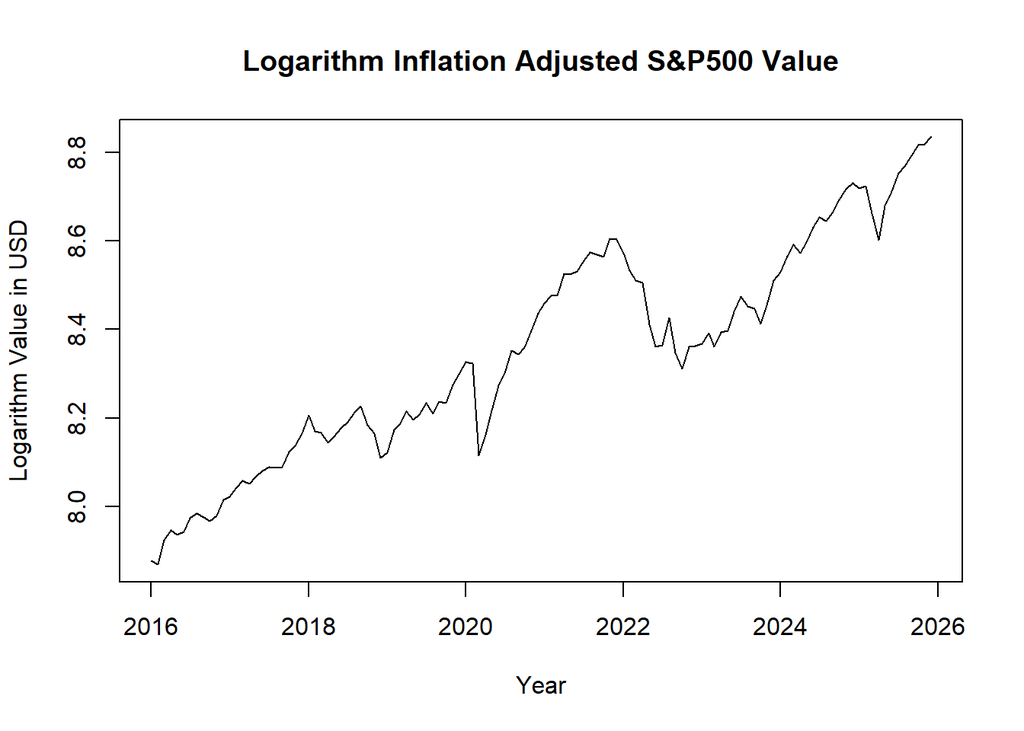

Notice that we still have the shape increases accounted for between 2020 and 2022, however the change is not nearly as wide, making a logarithm potentially be better suited.

We then can construct our new model. We use the same code as we did beforehand, only this time we will define new variables to ensure we do not confuse over selves between our models, as well as being able to compare them later on.

```r
LogTSModel=prophet(LogDataFrame, weekly.seasonality=FALSE, daily.seasonality=FALSE)
LogFutureDates= make_future_dataframe(LogTSModel, 8, freq="month")
LogPrediction=predict(LogTSModel, LogFutureDates)
```

We now can see how our new plot looks.

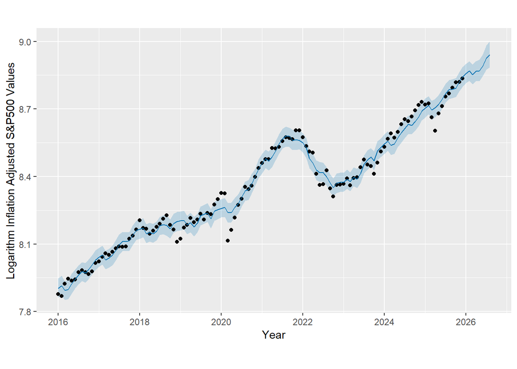

Notice that this model is seemingly following our data a lot more closely, which can account for the effect of the logarithm making our model a better suit. Furthermore, the issue we had before with our previous model not following the 2020-2022 period very well is gone, as now it has a much tighter and close fit to what the reality of the change in the S&P500 was.

However, we want to check if it is a better predictor than our previous model. When adjusted for logarithms, the actual value of the S&P500 was:

- January: 8.8434
- February: 8.8383
- March: 8.8279

According to our model, the logarithm adjusted values for the index are as follows.

```r
tail(LogPrediction[, c("ds","yhat")], 8)
```

```
##             ds     yhat
## 121 2026-01-01 8.857123
## 122 2026-02-01 8.869157
## 123 2026-03-01 8.852660
## 124 2026-04-01 8.867259
## 125 2026-05-01 8.869763
## 126 2026-06-01 8.892537
## 127 2026-07-01 8.925631
## 128 2026-08-01 8.942054
```

Now given we use logarithms, predict result is naturally closer to our estimate as we have greatly reduced it. However, even with that, we can observe that our model is quite accurate at predicting the value of our index, with it only being sometimes only about 0.03 out of the actual reality of the index’s evolution, making this a useful tool.

We now need to start to breakdown and analyse our components to our model. Our component breakdown can be seen below here, however we will go into a deeper breakdown for each part.

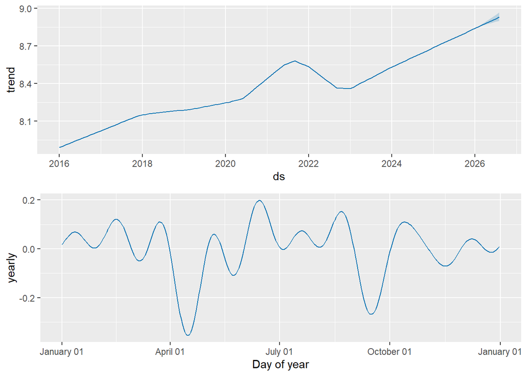

## Trend Component

We firstly need to isolate our trend component.

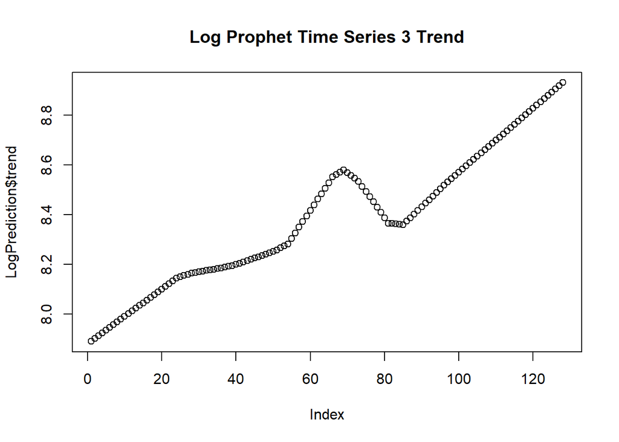

Now when analysing this components, we observe that:

- Our 2020-2022 period of uncertainty is modelled very accurately and correctly.
- Our period after 2022 seems to follow a more linear relationship, which we is in line with what we predicted beforehand.
- The model does continue to always predict growth, which without the seasonality component could be seen to be inaccurate and not true to reality.

However, with these observations, we can conclude an overall satisfaction with our trend component.

## Seasonality Component

We now begin to explore our seasonality.

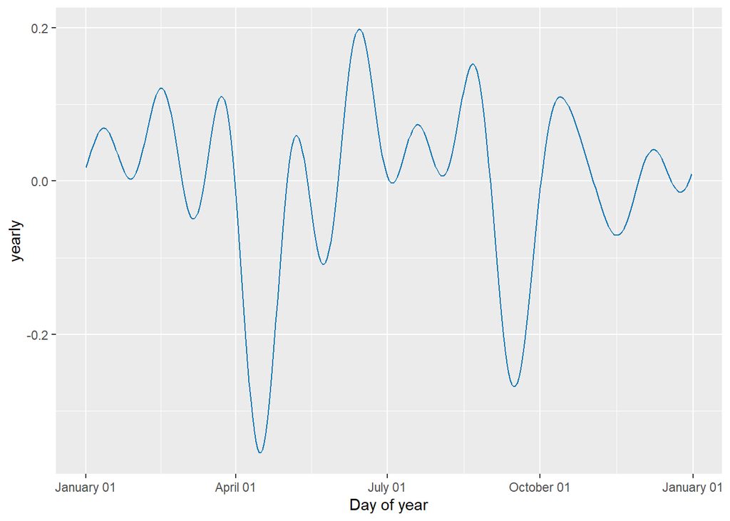

Overall, all of these observations have been things we would have otherwise expected given our previous model, leaving us feeling satisfied with the model overall so far. However, in order for this to be an effective time series, we need to check that our residuals follow a white noise pattern.

## Residuals

We calculate our residuals in the same way as we have done before, and once again we want to see them follow a random pattern in our plot.

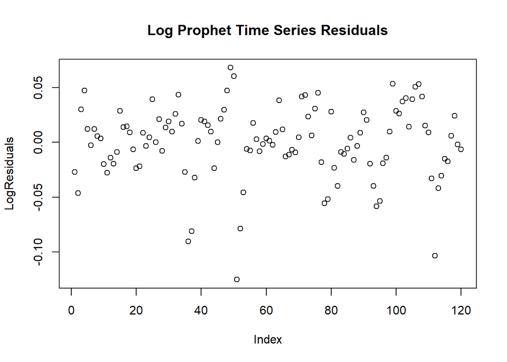

```r
LogResiduals= y - LogPrediction$yhat[1:nrow(LogDataFrame)]
plot(LogResiduals, main="Log Prophet Time Series Residuals")
```

Now, for these residuals, we can observe slight improvement, as there does appear to be a greatly element of randomness shown than there was beforehand. While we do have a bit of a pattern shown once again with the 2020-2022 period, this is not nearly as obvious as it once was, and is actually much more nuanced than it was before.

However, in order to get a clear idea whether our residuals are that of white noise, we need to conduct a Box Test again.

```r
Box.test(LogResiduals, type="Ljung-Box")
```

```
##
##  Box-Ljung test
##
## data:  LogResiduals
## X-squared = 38.495, df = 1, p-value = 5.489e-10
```

Our residuals have shown a vast improvement in their following of the white noise element, with our test statistic having decreased dramatically here from 100 to about 40. But even with this vast improvement, we do not have residuals following the white noise that we want them to, with this test indicating that there is still a pattern present to them that we do not want to see.

## Removing Seasonality

Once again, in order to investigate whether fulfil our residual requirement, we try to remove seasonality again. Our trend component will remain the same as it did before, so we will just continue to doing the plot and test for our residuals.

[figure not shown]

```r
LogTSModel2= prophet(LogDataFrame, yearly.seasonality = FALSE, weekly.seasonality=FALSE, daily.seasonality=FALSE)
LogFutureDates2= make_future_dataframe(LogTSModel2, 8, freq="month")
LogPrediction2= predict(LogTSModel2, LogFutureDates2)
LogResiduals2= y - LogPrediction2$yhat[1:nrow(LogDataFrame)]
plot(LogResiduals, main="Prophet Log Time Series without Seasonality Residuals")
```

We have a similar plot to before, however we can only verify if we have passed the test for our residuals being white noise.

```r
Box.test(LogResiduals2, type="Ljung-Box")
```

```
##
##  Box-Ljung test
##
## data:  LogResiduals2
## X-squared = 36.71, df = 1, p-value = 1.371e-09
```

Similarly to our last model, removing seasonality does improve the result of our model, however it does not improve it by enough for us to fufill the requirement of the residuals being distributed according to white noise.

# Section 5: Percentage Change?

There is one final way that we could see about fitting the change of the inflation adjusted S&P500 index to a time, and that is by trying to utilise percentage change.

## Fitting Model

To fit the model, we firstly need to ensure that we convert our y data back to the original values, which we can do by just doing the exponential function.

```r
y=exp(y)
```

We then have to define our new variable of percentage change. In doing percentage change, we need to find the difference in values between month to month, and then divide it by the original value, which we are able to do below.

```r
pct_change = c(NA, diff(DataFrame$y) / head(DataFrame$y, -1))
```

Note that our first value for this must be NA, as we cannot look at the percentage change for the first month as we don’t have data from the previous month.

We then can create our new data frame, whereby we need to continue to use the ds and y naming trend to ensure prophet can model our data.

```r
PCTDataFrame= data.frame(ds=ds, y=pct_change)
```

However, recall that our data frame has the first value of NA, which we need to remove to ensure we only have numerical percentage changes.

```r
PCTDataFrame= PCTDataFrame[-1,]
pct_change= pct_change[-1]
```

We can then create our model in the same way that we have beforehand.

```r
PCTTSModel= prophet(PCTDataFrame, weekly.seasonality=FALSE, daily.seasonality=FALSE)
PCTFutureDates= make_future_dataframe(PCTTSModel, 8, freq="month")
PCTPrediction= predict(PCTTSModel, PCTFutureDates)
```

And when we plot our new time series, we can see the following.

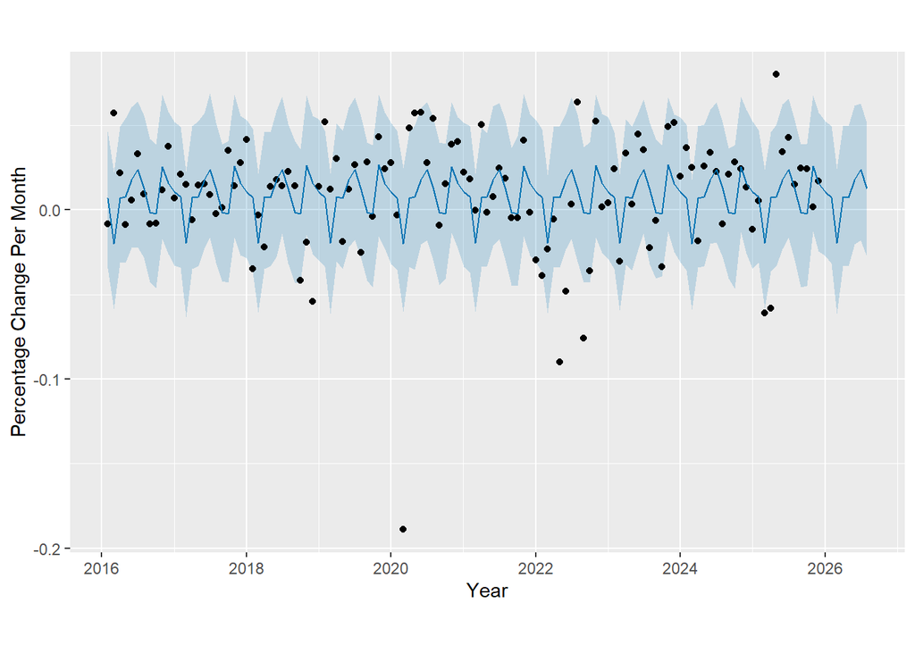

Now, from this plot we can obverse that:

- Our 2020-2022 period is much more fitting and line line with our model.
- 2020 saw a sharp decrease in value far beyond the rest of our plot, which is in line with the 2020 COVID19 pandemic and the effect it had.
- The index does generally appear to often grow with smaller periods of decrease in value.

But most importantly, we want to see how accurate our model is to the real word. For the last 3 months, the percentage change was:

- January: 0.00738
- February: -0.00510
- March: -0.01036

When looking at our model, we see the predicted change was.

```r
tail(PCTPrediction[, c("ds","yhat")], 8)
```

```
##             ds         yhat
## 120 2026-01-01  0.010572213
## 121 2026-02-01  0.007350970
## 122 2026-03-01 -0.019626169
## 123 2026-04-01  0.007630054
## 124 2026-05-01  0.007315367
## 125 2026-06-01  0.017916788
## 126 2026-07-01  0.023935371
## 127 2026-08-01  0.012354192
```

We can now begin to explore the components of our new model.

## Trend Component

We first extract our Trend Component.

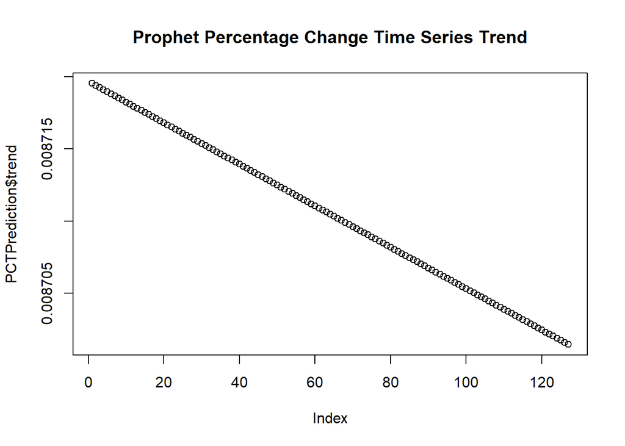

Now from this plot, we can see a heavy dependence on the seasonality of our model, as the trend component would have us assume that the index is consistently increasing each month, however is decreasing it how much it increases the more than time goes on. This can be an unrealistic assumption, so we need to investigate our seasonality.

## Seasonality Component

We can see the seasonality of our model below.

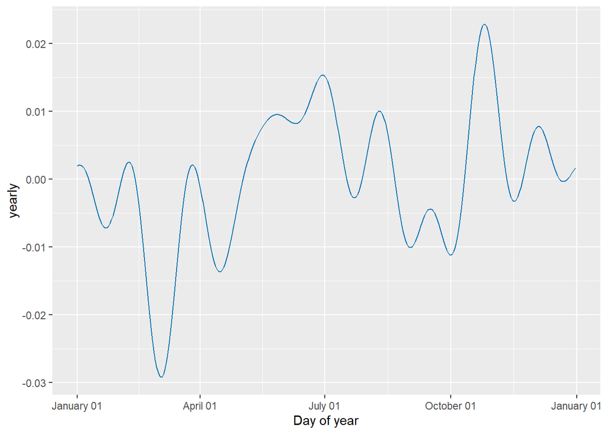

This is seasonality that is in line with some of the observations that we have made beforehand, while there also being some new observations present as well:

- March time is often when the index experiences the greatest dip in value, having a decrease of 3%.
- Q4 has the index rise greatly in value, with the highest increase coming between October and January.
- Q2-Q3 is mostly about recovery from the previously mentioned March dip.
- There is a slight dip between the end of August to start of October, making this a potentially sluggish period for industry.

However given our trend data, we are left in a position where our residuals could be mostly determined by this seasonality, which could create issues with our required white noise assumption.

## Residuals

We now calculate our residuals and plot them.

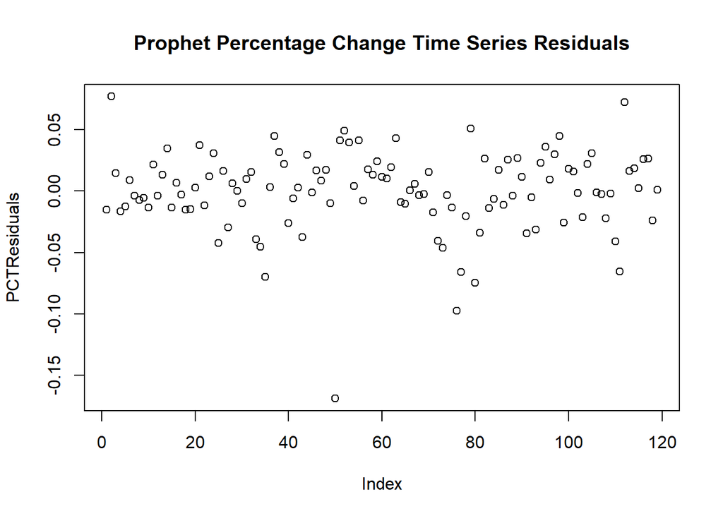

```r
PCTResiduals= pct_change - PCTPrediction$yhat[1:nrow(PCTDataFrame)]
plot(PCTResiduals, main="Prophet Percentage Change Time Series Residuals")
```

Now for these residuals, we do have a fairly even random distribution with this is the model with the most random residuals, giving us confidence for having white noise residuals. However, we do appear to have an extreme value, which is potentially from when markets declined due to COVID. Once again, we need to conduct our Box Test to ensure our residuals are white noise.

```r
Box.test(PCTResiduals, type="Ljung-Box")
```

```
##
##  Box-Ljung test
##
## data:  PCTResiduals
## X-squared = 0.78225, df = 1, p-value = 0.3765
```

Now, when looking at the X-squared value we have, we have the lowest value we have yet by a considerable margin. This then leads us to our p-value, which is at 0.3765, meaning we have satisfied our null hypothesis that our residuals follow a white noise distribution that we so require. As a result, we are indeed able to model the value of the inflation adjusted S&P500 value via a time series using prophet.

# Overall Conclusion

In looking at the S&P500 index, we have tried to fit many time series to it and predict it’s future values many times. We have attempted to fit a time series using it’s original values and using the logarithm of it’s values. Despite these other models, we have been able to determine that the best and most accurate way of modelling this is by investigating the percentage change month to month for the index. In doing this, we not only have residuals distributed according to white noise, but we have also been able to conclude that the increase of the index is starting to decrease and slow, with the seasonality of the month being what can be indicate and predict it’s change in value, with it being common for the end of Q1 and start of Q2 to see the index dip in value, upon which it starts to then increase and pick up again. This means that, for a long term investor, this is the period of time in which to invest, however the returns may not continue at the rate they once have.

Source of Information for Index: https://www.multpl.com/inflation-adjusted-s-p-500

# References

- Datacamp course: https://www.datacamp.com/courses/reporting-with-rmarkdown
- RStudio reference: https://rmarkdown.rstudio.com/lesson-1.html
- More sophisticated reference: https://bookdown.org/yihui/rmarkdown/